# Evaluación y refinamiento

# Part 3: Ridge Regression

En esta sección, revisaremos Ridge Regression y veremos cómo el parámetro alfa cambia el modelo. Solo una nota, aquí nuestros datos de prueba se utilizarán como datos de validación.

Realicemos una transformación polinomial de grado dos en nuestros datos.

```python
pr=PolynomialFeatures(degree=2)
x_train_pr=pr.fit_transform(x_train[['horsepower', 'curb-weight', 'engine-size', 'highway-mpg','normalized-losses','symboling']])
x_test_pr=pr.fit_transform(x_test[['horsepower', 'curb-weight', 'engine-size', 'highway-mpg','normalized-losses','symboling']])
```

```python
from sklearn.linear_model import Ridge
```

```python
RigeModel=Ridge(alpha=1)
```

```python
RigeModel.fit(x_train_pr, y_train)
```

```
Ridge(alpha=1)
```

```python
yhat = RigeModel.predict(x_test_pr)
```

```python
print('predicted:', yhat[0:4])
print('test set :', y_test[0:4].values)
```

```
predicted: [ 6570.82441941  9636.24891471 20949.92322738 19403.60313256]
test set : [ 6295. 10698. 13860. 13499.]
```

Seleccionamos el valor de alfa que minimiza el error de prueba. Para hacerlo, podemos usar un bucle for. También hemos creado una barra de progreso para ver cuántas iteraciones hemos completado hasta ahora.

```python
from tqdm import tqdm

Rsqu_test = []
Rsqu_train = []
dummy1 = []
Alpha = 10 * np.array(range(0,1000))
pbar = tqdm(Alpha)

for alpha in pbar:
    RigeModel = Ridge(alpha=alpha)
    RigeModel.fit(x_train_pr, y_train)
    test_score, train_score = RigeModel.score(x_test_pr, y_test), RigeModel.score(x_train_pr, y_train)

    pbar.set_postfix({"Test Score": test_score, "Train Score": train_score})

    Rsqu_test.append(test_score)
    Rsqu_train.append(train_score)
```

Podemos trazar el valor de R^2 para diferentes alfas:

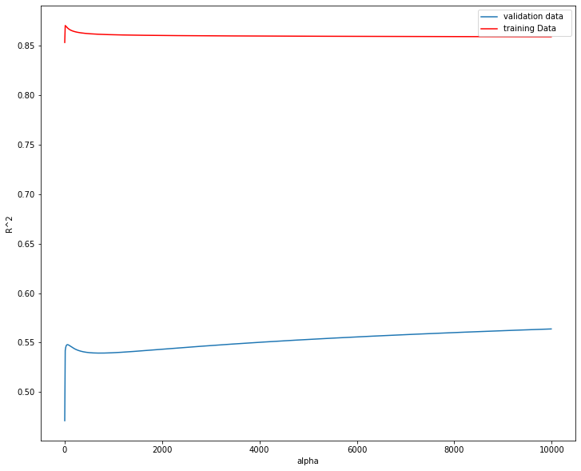

```python
width = 12
height = 10
plt.figure(figsize=(width, height))

plt.plot(Alpha,Rsqu_test, label='validation data  ')
plt.plot(Alpha,Rsqu_train, 'r', label='training Data ')
plt.xlabel('alpha')
plt.ylabel('R^2')
plt.legend()
```

Figura 4: La línea azul representa el R^2 de los datos de validación y la línea roja representa el R^2 de los datos de entrenamiento. El eje x representa los diferentes valores de Alpha.

La línea azul representa el R^2 en los datos de validación. A medida que aumenta el valor de alfa, R ^ 2 aumenta y converge en un punto.

```python
RigeModel = Ridge(alpha=10)
RigeModel.fit(x_train_pr, y_train)
RigeModel.score(x_test_pr, y_test)
```

```
0.5418576440208465
```

# Part 4: Grid Search

El término alfa es un hiperparámetro. Sklearn tiene la clase GridSearchCV para simplificar el proceso de encontrar el mejor hiperparámetro.

Importemos GridSearchCV desde el módulo model_selection.

```python
from sklearn.model_selection import GridSearchCV
```

We create a dictionary of parameter values:

```python
parameters1= [{'alpha': [0.001,0.1,1, 10, 100, 1000, 10000, 100000, 100000]}]
parameters1
```

```
[{'alpha': [0.001, 0.1, 1, 10, 100, 1000, 10000, 100000, 100000]}]
```

Create a Ridge regression object:

```python
RR=Ridge()
RR
```

```
Ridge()
```

Create a ridge grid search object:

```python
Grid1 = GridSearchCV(RR, parameters1,cv=4)
```

Ajuste el modelo:

```python
Grid1.fit(x_data[['horsepower', 'curb-weight', 'engine-size', 'highway-mpg']], y_data)
```

```
GridSearchCV(cv=4, estimator=Ridge(),
             param_grid=[{'alpha': [0.001, 0.1, 1, 10, 100, 1000, 10000, 100000,
                                    100000]}])
```

El objeto encuentra los mejores valores de parámetros en los datos de validación. Podemos obtener el estimador con mejores parámetros y asignarlo a la variable BestRR de la siguiente manera:

```python
BestRR=Grid1.best_estimator_
BestRR
```

```
Ridge(alpha=10000)
```

We now test our model on the test data:

```python
BestRR.score(x_test[['horsepower', 'curb-weight', 'engine-size', 'highway-mpg']], y_test)
```

```
0.8411649831036148
```